# Strategie rozwiązywania zadań-PISA2015

Wioleta Stojak, Szymon Majewski, Piotr Podolski

8 stycznia 2017

# Obróbka danych

## Wykorzystane pakiety

```r
library(MASS)
library(cluster)
library(ggplot2)
library(factoextra)
library(ggfortify)
library(dendextend)
library(stats)
library(ape)
```

# Statystyki czasu rozwiązywania zadań dla szkól

Dla każdej ze szkoły stworzylismy nastepujące statystyki:

- średnia czasu rozwiazywania zadania przez studentów z każdej pozycji testu z podziałem na matematyke i czytanie
- kwantyl rzędu 0.25 czasu rozwiazywania zadania przez studentów dla każdej pozycji testu z podziałem na matematyke i czytanie
- kwantyl rzędu 0.75 czasu rozwiazywania zadania przez studentów dla każdej pozycji testu z podziałem na matematyke i czytanie
- średnie odchylenie standardowe czasu rozwiązywania zadania przez studenta z podziałem na matematyke i czytanie
- średni maksymalny czas rozwiązywania zadania przez studenta z podziałem na matematyke i czytanie
- średni maksymalny kwantyl rzędu 0.75 czasu rozwiązywania zadania przez studenta z podziałem na matematyke i czytanie

Pojawiające się wartości **NA** uzupełnilismy srednią z danej kolumny. Postanowiliśmy odrzucić szkoły, które miały mniej niz 20 studentów.

# Metody redukcji wymiaru

Przedstawiamy następujące metody redukcji wymiaru (do wymiaru = 2) oparte o zbiór statystyk dla danej szkoły.

- Analiza składowych głównych (**PCA**)
- Skalowanie niemetryczne z użyciem funkji **isoMDS**
- Skalowanie metryczne z użyciem funkcji **cmdscale**

Ponadto do każdej z powyżych motod (na 20% danych ze względu na czas obliczeń) przedstawiony został **diagram Sheparda**. Wykres ten przedstawia odtworzone odległości wykreślone na osi pionowej względem pierwotnych niepodobieństw wykreślonych na osi poziomej. Jeśli wszystkie odtworzone odległości znajdowałyby się na linii krokowej, to porządek rangowy odległości (lub niepodobieństw) byłby dokładnie odtworzony. Odchylenia od linii krokowej wskazują na brak dopasowania.

Interpretacja: Rysunek poniżej przedstawia autoplot, na którym umieszczone są dwa wykresy. Jeden przedstawia indeksy obserwacji przedstawione na układzie współrzędnych określonych przez dwie pierwsze składowe główne (w tym przypadku dwie współrzędne wyjaśniają około 60% całej zmienności). Drugi rysunek przedstawia kierunki w których działają oryginalne zmienne, innymi słowy przedstawiają jak wartość danej zmiennej wpływa na wartości dwóch pierwszych składowych głównych. Jeżeli wektory mają przeciwne zwroty to dane zmienne są ujemnie skorelowane (nie można jednak ocenić wartości korelacji), jeżeli zwroty są prostopadłe to zmienne są nieskorelowane, a jeżeli zwroty są bliskie to zmienne są dodatnio skorelowane.

## PCA

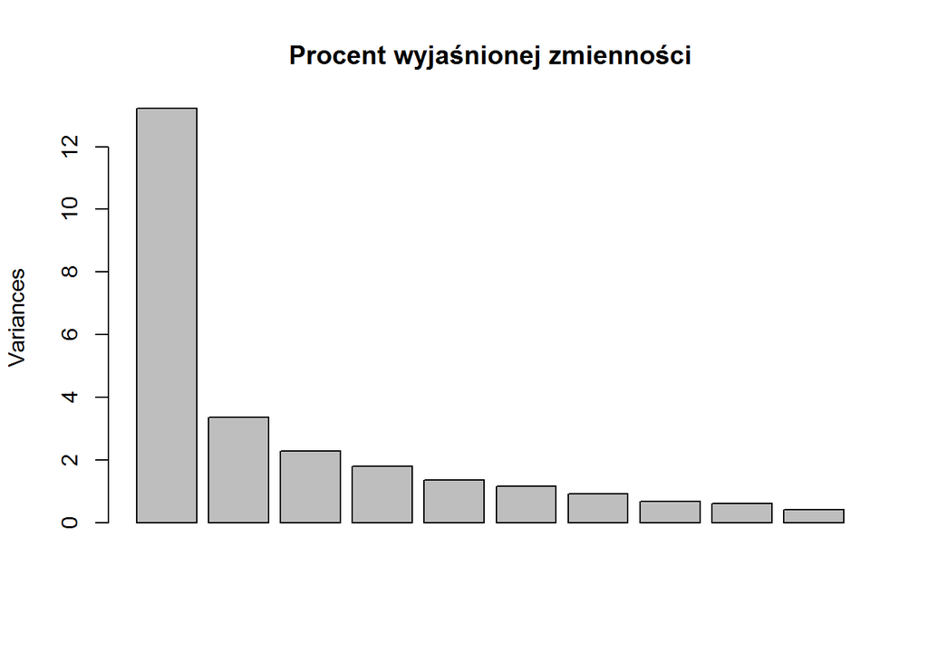

```
## Importance of components:
##                           PC1    PC2     PC3     PC4     PC5    PC6
## Standard deviation     3.6368 1.8327 1.50852 1.34024 1.16063 1.0779
## Proportion of Variance 0.4724 0.1200 0.08127 0.06415 0.04811 0.0415
## Cumulative Proportion  0.4724 0.5923 0.67361 0.73776 0.78587 0.8274
##                            PC7     PC8     PC9    PC10    PC11   PC12
## Standard deviation     0.95655 0.82715 0.77358 0.63667 0.56836 0.5371
## Proportion of Variance 0.03268 0.02443 0.02137 0.01448 0.01154 0.0103
## Cumulative Proportion  0.86004 0.88448 0.90585 0.92033 0.93186 0.9422
##                           PC13    PC14    PC15    PC16   PC17    PC18
## Standard deviation     0.49725 0.49226 0.46793 0.42597 0.3853 0.33518
## Proportion of Variance 0.00883 0.00865 0.00782 0.00648 0.0053 0.00401
## Cumulative Proportion  0.95100 0.95965 0.96747 0.97395 0.9792 0.98327
##                           PC19    PC20    PC21    PC22    PC23    PC24
## Standard deviation     0.31259 0.25476 0.24659 0.23177 0.21614 0.21065
## Proportion of Variance 0.00349 0.00232 0.00217 0.00192 0.00167 0.00158
## Cumulative Proportion  0.98676 0.98907 0.99125 0.99316 0.99483 0.99642
##                           PC25    PC26    PC27    PC28
## Standard deviation     0.18036 0.17081 0.14891 0.12824
## Proportion of Variance 0.00116 0.00104 0.00079 0.00059
## Cumulative Proportion  0.99758 0.99862 0.99941 1.00000
```

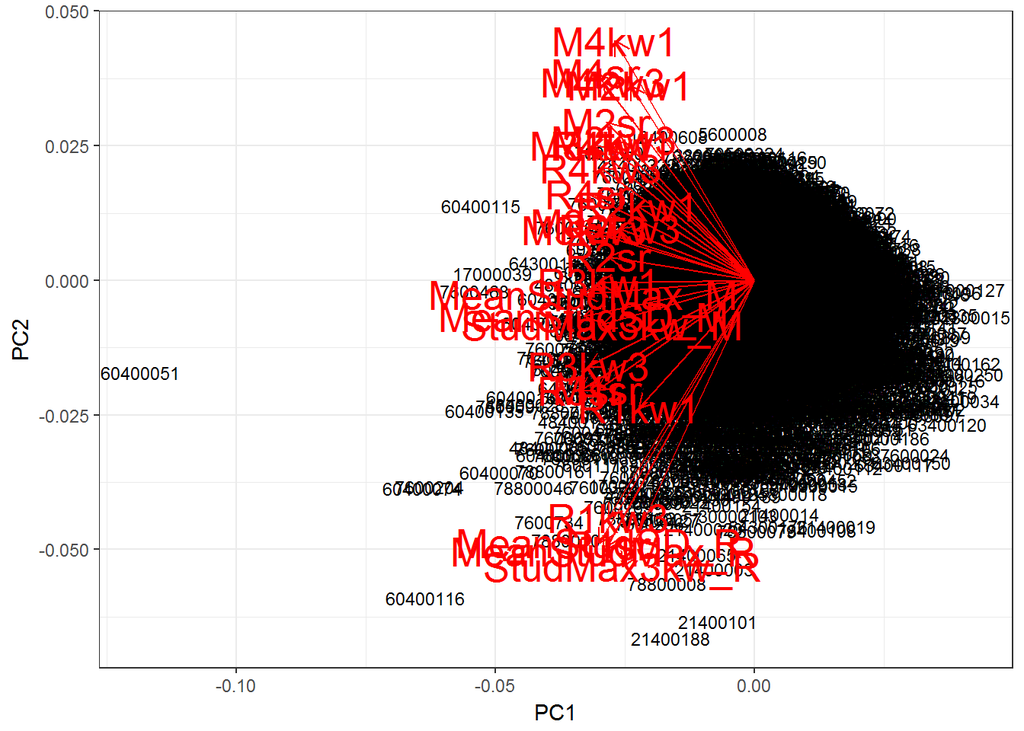

```
##                 PC1        PC2
## 3600003 -2.53448633 -2.3694994
## 3600004  1.82060224  2.8684792
## 3600007  4.10615170 -1.1545712
## 3600009  4.46065083 -0.7181905
## 3600026 -2.13883343  0.2128428
## 3600041 -0.14790418  1.7589699
## 3600046 -0.08491114  0.7978534
## 3600062  1.19938502  0.8286172
## 3600068  6.10322572 -0.3849292
## 3600077 -0.30705782 -0.1680431
```

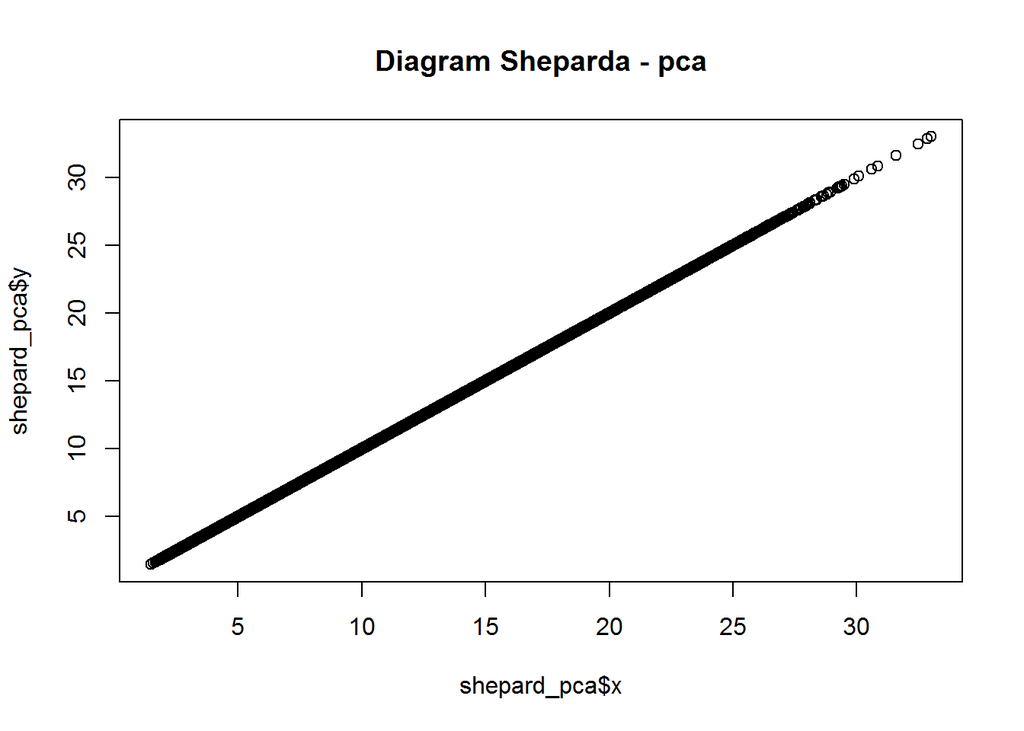

## Skalowanie metryczne

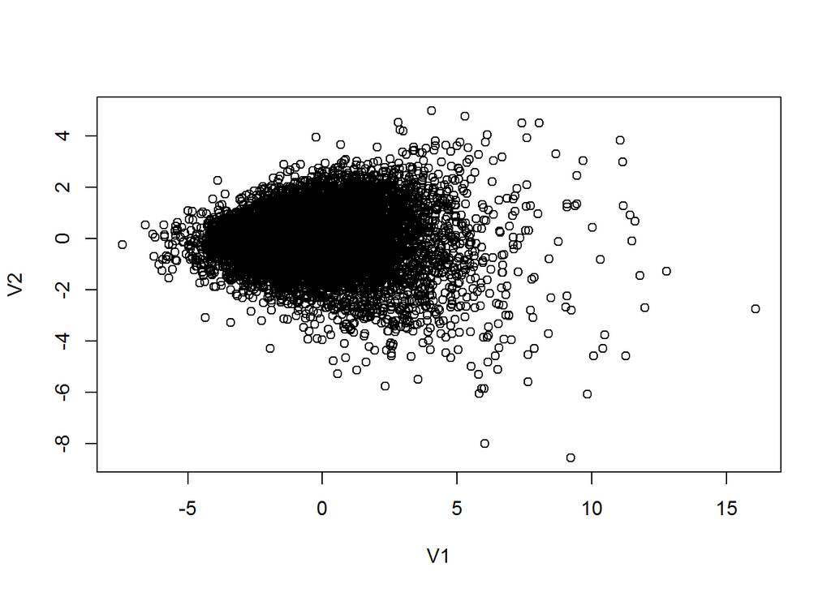

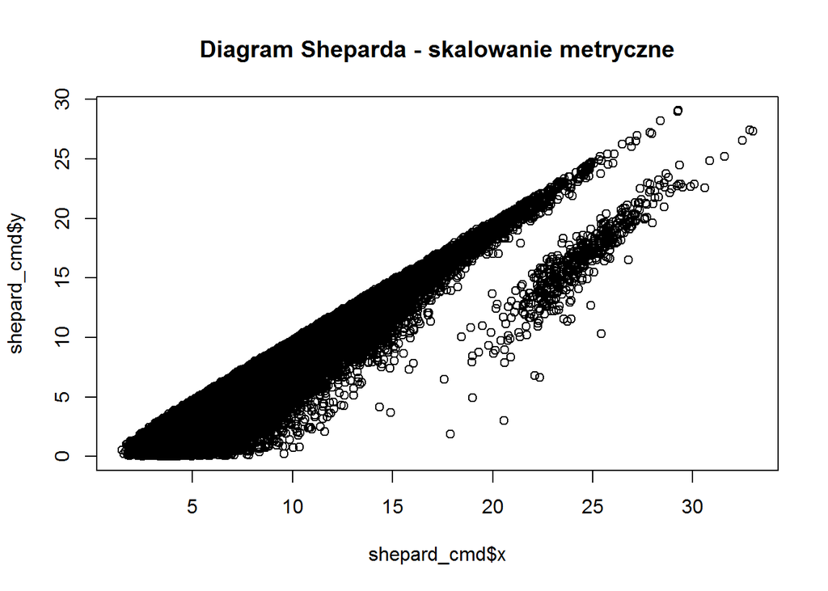

## skalowanie niemetryczne

```
## List of 2
##  $ points: num [1:9518, 1:2] 2.53 -1.82 -4.1 -4.46 2.14 ...
##   ..- attr(*, "dimnames")=List of 2
##   .. ..$ : chr [1:9518] "3600003" "3600004" "3600007" "3600009" ...
##   .. ..$ : NULL
##  $ stress: num 19.6
```

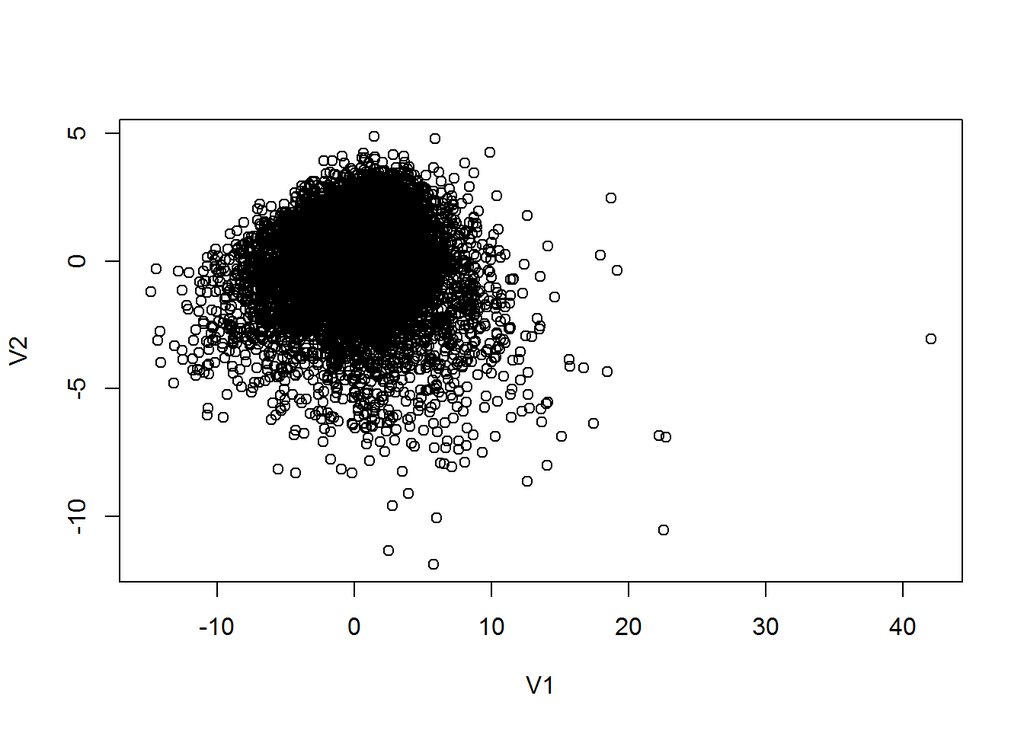

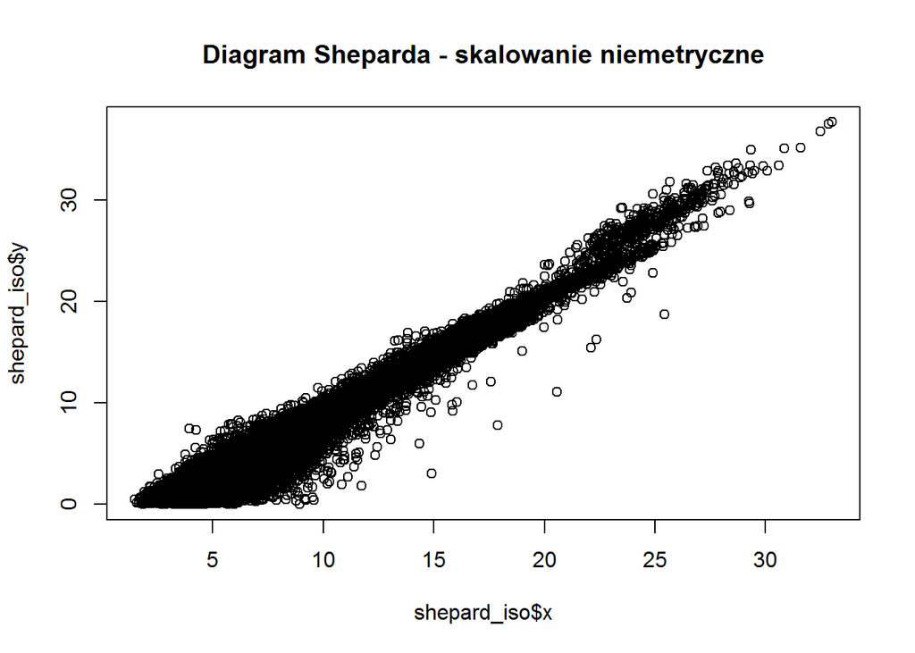

# Analiza hierarchiczna

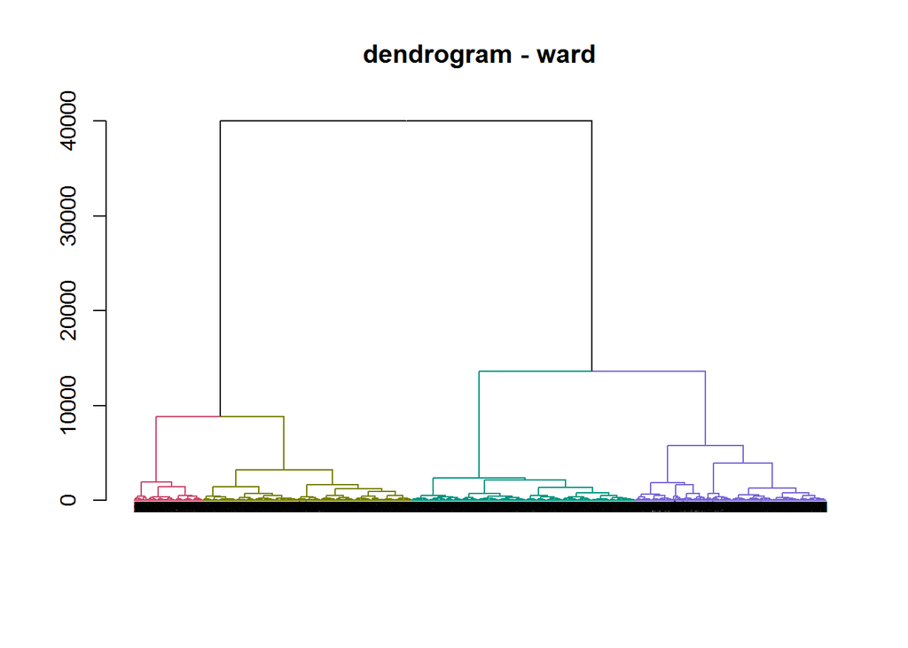

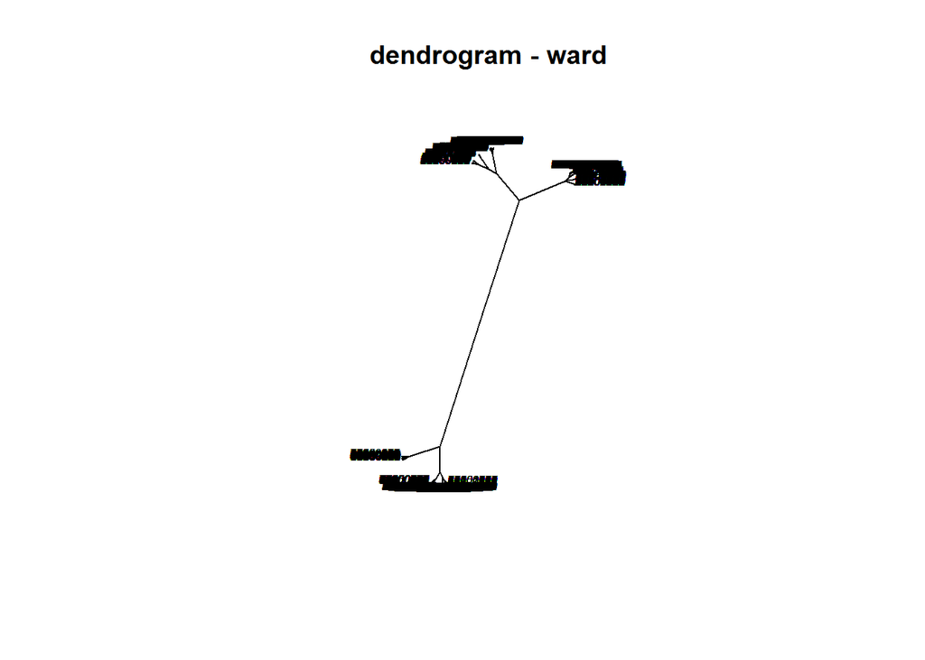

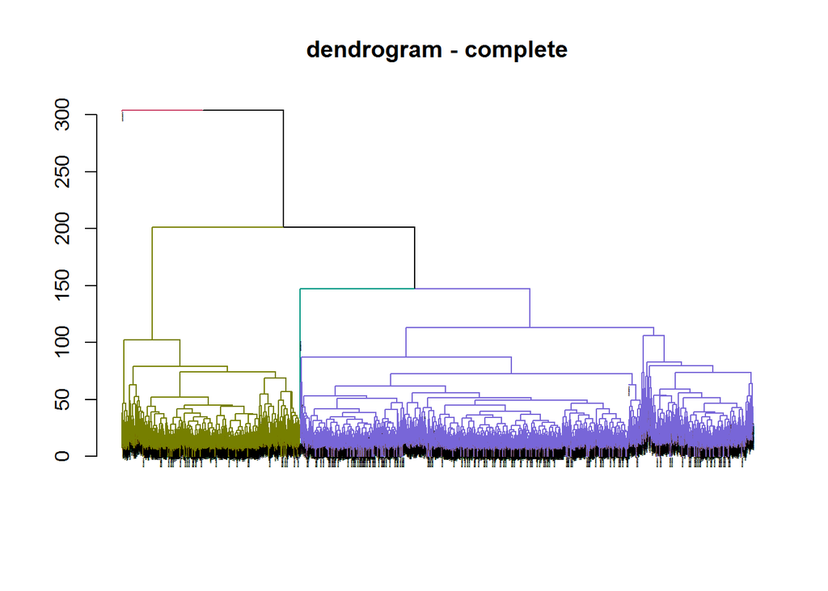

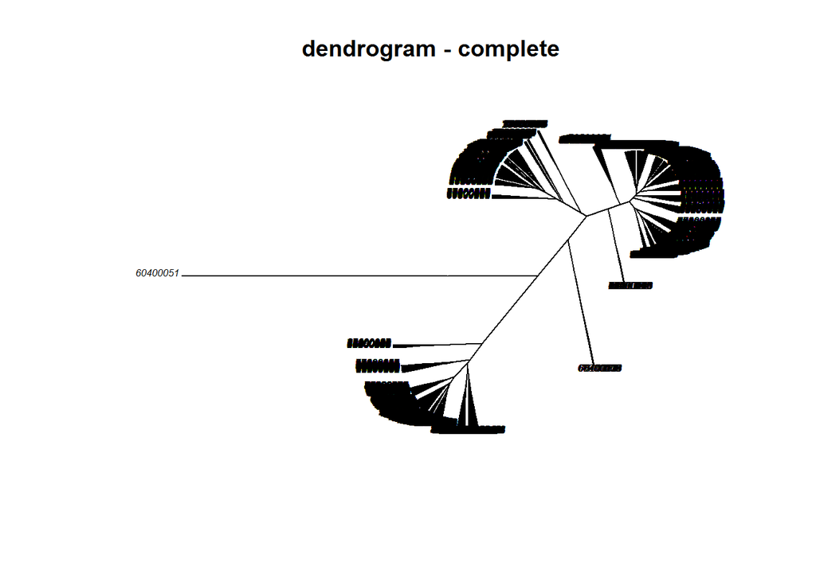

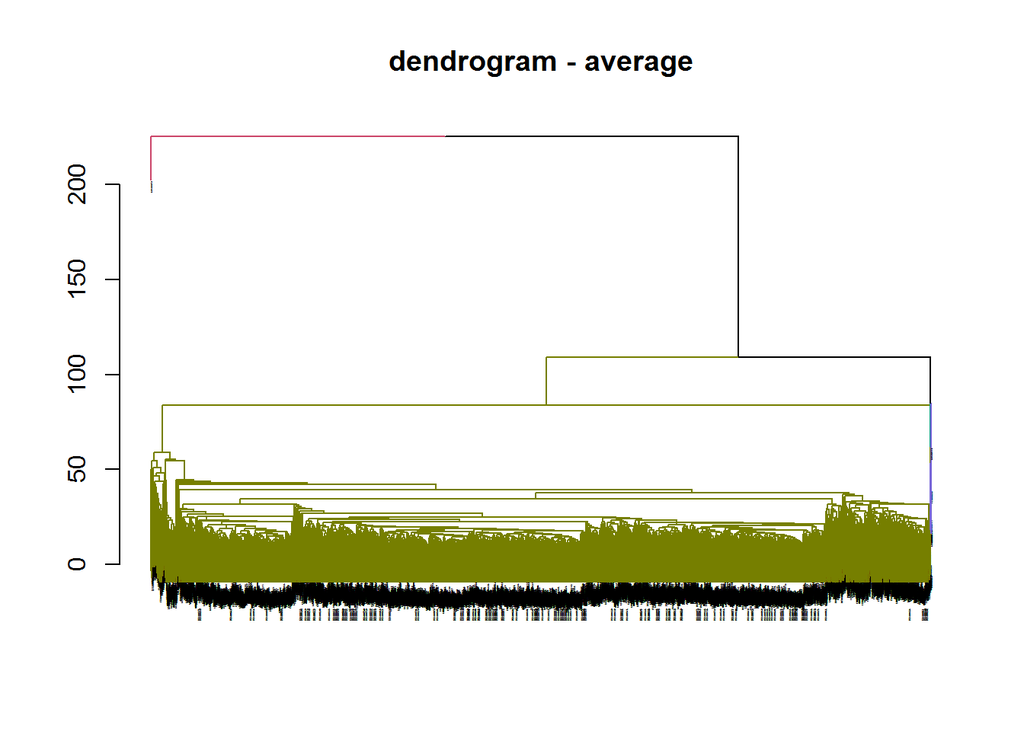

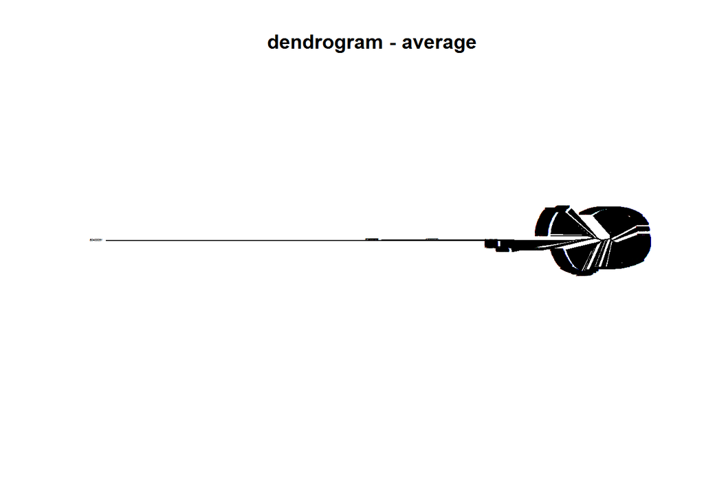